# An introduction to Momocs

Vincent Bonhomme

2022-03-31

## News

- As of Apr. 2022, I’m looking for funding and thus time to finish MomX. Some of it below may become obsolete but it’s quite often demanded so I brought it back to life.
- As of Oct. 2018, Momocs is being extensively polished these days and may evolve before its 2.0 release as part of [MomX](http://momx.online).

## Preliminaries

### Abstract

Momocs aims to provide a complete and convenient toolkit for morphometrics. It is intended for scientists interested in describing quantitatively the shape, and its (co)variations, of the objects they study.

In the last decade, R has become the open-source *lingua franca* for statistics, and morphometrics known its so-called “revolution”. Nevertheless, morphometric analyses still have to be carried out using various software packages either dedicated to a particular morphometric and/or for which source code is mostly unavailable and/or copyrighted. Moreover, most of existing software packages cannot be extended and their bugs are hard to detect and thus correct. This situation is detrimental to morphometrics: time is wasted, analyses are restricted to available methods, and last but not least, are poorly reproducible. This impedes collaborative effort both in software development and in morphometric studies.

By gathering the common morphometric approaches in an open-source environment and welcoming contributions, Momocs is an attempt to solve this twofold problem.

Momocs hinges on the core functions published in the must-have *[Morphometrics with R](http://www.springer.com/us/book/9780387777894)* by [Julien Claude](http://www.isem.univ-montp2.fr/recherche/equipes/macroevolution-et-developpement/personnel/claude-julien/) (2008), but has been further extended to allow other shape description systems. So far, configurations of landmarks, outlines and open outline analyses, along with some facilities for traditional morphometrics are implemented.

Prior to analysis, Momocs can be used to acquire and manipulate data or to import/export from/to other formats. Momocs also has the facility for a wide range of multivariate analyses and production of the companion graphics. Thus a researcher will find that just a few lines of code will provide initial results, but the methods implemented can be finely tuned and extended according to the user’s needs.

- If you use it, please cite it: `citation("Momocs")`.
- This citation refers to an obsolete version of Momocs, only handling outline analyses. The next companion, encompassing all [MomX](http://momx.online) and seminal paper is on its way.

### Survival tips

- This vignette introduces Momocs, as for every R function, each function has its own manual page, eg `?efourier`.
- There is a much nicer [online version of this manual](http://momx.github.io/Momocs/) that can be accessed from the console with, e.g. `Momocs_help("efourier")`.
- Feel free to contribute to Momocs through [GitHub](http://www.github.com/MomX/Momocs): report issues, ask for new features, share data and methods, correct typos, write better vignettes, helpfiles, or whatever pleases you. If you have never heard of GitHub, that’s definitely worth [a look](http://r-pkgs.had.co.nz/git.html).
- Feel free to drop me a line, should you need a hand or would like to collaborate with me: `bonhomme.vincent@gmail.com`.
- Before asking for help, please read Momocs’s FAQ: `vignette("Momocs_FAQ")`.

### Get, install and use it

First, of all, let’s download the last version of Momocs. You will need to install the `devtools` package - if you do not have it yet - to get it from my [GitHub](http://www.github.com/MomX/Momocs) repository :

```r
install.packages("devtools")
devtools::install_github("MomX/Momocs")
```

The typical `install_packages("Momocs")` will get you the last CRAN version of Momocs, but the GitHub version is preferred as Momocs is still under active development.

We can start using Momocs, as long as it has been loaded using:

```r
library(Momocs)
```

Future versions of Momocs (and MomX at some point) will totally embrace the tidyverse. My best advice if you’re doing regular data science using R and if you do not master it yet is : i) to have a look at it https://www.tidyverse.org/ and ii) to have more than a look at it.

*One important point is you use tidyverse or any of its packages (dplyr, purrr, etc.) is to load them **before** Momocs, ie :

```r
library(tidyverse)
library(Momocs)
```

## Design

Keywords used all accross Momocs are introduced here in **bold**.

Morphometrics is the ugly job of turning beautiful shapes into quantitative variables. Just kidding, that’s pretty exciting.

A **shape** is defined as a collection of `(x; y)` coordinates. No 3D yet but different **families** are handled by Momocs:

1. **outlines**, here in a first-quarter moon ;
2. **open outlines**, here is the sterile valve of an olive stone;
3. **configuration of landmarks**; here, homologous points from a mosquito wing.

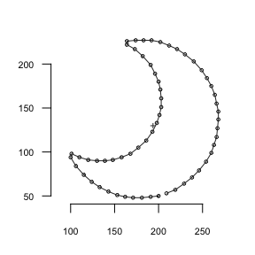

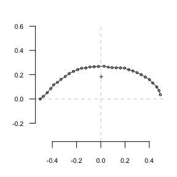

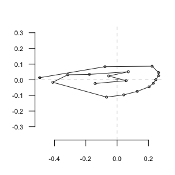

They are all single shapes defined by a matrix of `(x; y)` coordinates; here are the first points of the moon:

```r
shapes[18] %>% head()
```

```
##      [,1] [,2]
## [1,]  200   50
## [2,]  199   49
## [3,]  198   49
## [4,]  197   50
## [5,]  196   50
## [6,]  195   49
```

Many operations on shapes are implemented such as: plotting, geometric operations, scalar descriptions, etc. These operations have their dedicated vignette, see `vignette("Momocs_coo")`.

Working on single shape can quicly be boring. Shapes can be organized into a collection of coordinates: a `Coo` object that carries:

- a component named `$coo`, a `list` of shapes (as `matrix`.ces);
- most of the time, a component named `$fac`, a `data.frame` (or the modern equivalent, a `data_frame`) to store covariates, either `factor`s or `numeric`s;
- possibly, other components of interest.

One can do several things with a `Coo` object: visualize it, apply morphometric operations, handle the data it contains, but in the end, a __ morphometric method__ will turn coordinates into coefficients.

Such morphometric operation on coordinates produce a collection of coefficients: a `Coe` object that carries:

- a component named `$coe`, a `matrix` of coefficients;
- if present in `Coo`, `$fac` is inherited;
- possibly, other components of interest.

This can be summarized as follows:

| `Coo` | + | Morphometric method | = | `Coe` |
| --- | --- | --- | --- | --- |
| `(x; y)` coordinates | + | appropriate method | = | quantitative variables |

`Coo` objects are collections of coordinates that become `Coe` objects when an appropriate morphometric method is applied on them.

Some operations on `Coo`/`Coe` are **generic** in that they do not depend of the nature of the shape. For instance, centering a configuration of landmarks or an outline, or calculating their centroid size is, mathematically, the same **generic** operation. But some operations on shapes are **specific** to a peculiar family. For instance, calculating elliptical Fourier transforms on a configuration of landmarks would make no sense.

Momocs implement this desirable behavior and defines **classes** and **subclasses**, as S3 objects.

| `Coo` | Morphometrics methods | `Coe` |
| --- | --- | --- |
| `OutCoo` (outlines) | `efourier`, `rfourier`, `sfourier`, `tfourier` | `OutCoe` |
| `OpnCoo` (open outlines) | `npoly`, `opoly`, `dfourier` | `OpnCoe` |
| `LdkCoo` (configuration of landmarks) | `fgProcrustes`, `slide` | `LdkCoe` |

In other words:

- any collection of shapes belongs to (pick one) `{OutCoo, OpnCoo, LdkCoo}` and is also a `Coo` object;
- generic and specific methods can be applied to it
- a collection of coefficients is obtain and belongs to (pick one) `{OutCoe, OpnCoe, LdkCoe}` and is also a `Coe` object.

Finally, generic and specific operations can be applied to the `Coe` objects, chiefly multivariate methods, capitalicized: `PCA`, `LDA`, `CLUST`, `MANOVA`(and MANCOVA), `MSHAPES`, `KMEANS`, etc.

Overall, Momocs implements a simple and consistent grammar that is detailed below. Also, if you’re familiar with modern R and the Hadley-verse, you should feel home as `ggplot2` graphics, `dplyr` verbs and `magrittr` pipes are implemented.

## Single shapes

Let’s load one of the Momocs datasets, some various outlines (an `Out` object):

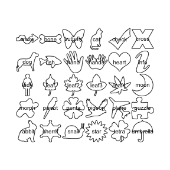

```
## Out (outlines)
##   - 30 outlines, 836 +/- 255 coords (in $coo)
##   - 0 classifiers (in $fac):
## # A tibble: 0 × 0
##   - also: $ldk
```

```r
shapes                    # prints a brief summary
panel(shapes, names=TRUE) # base graphics
```

`shapes` is one of the datasets bundled with Momocs. It’s (“lazy”) loaded in memory as soon as you call it, no need for `data(shapes)`. To see all Momocs’ datasets, try `data(package="Momocs")`. These datasets are all `Coo` objects (try `class(bot)`), ie collection of shapes.

One can do many things on a `Coo` object, as above, eg printing a summary of it (just by typing its name in the console), plotting a family picture with `panel`, etc.

So far, we’re interested in single shapes so let’s extract the 4th shape from `shapes`, using the traditional syntax. We plot it with `coo_plot` that comes with several options for plotting all families of shapes.

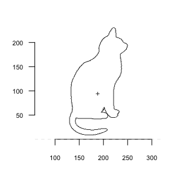

```r
shp <- shapes[4]
coo_plot(shp)
```

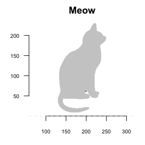

```r
# coo_plot is the base plotter for shapes
# but it can be finely customized, see ?coo_plot
coo_plot(shp, col="grey80", border=NA, centroid=FALSE, main="Meow")
```

Let’s now do some basic operations on this shape. They all named `coo_*` and you can have the full list with `apropos("coo_")`. `coo_*` family encompasses:

- geometric operations (such as centering, scaling, etc.)
- plotting functions
- scalar descriptors of shape (such as area, perimeter, circularity, rectilinearity, etc.)
- various other operations on a single shape.

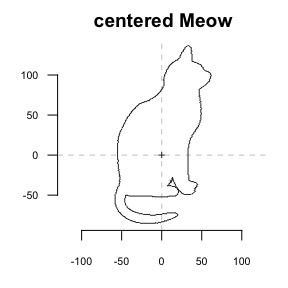

```r
coo_plot(coo_center(shp), main="centered Meow")
```

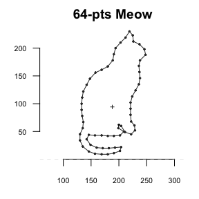

```r
coo_plot(coo_sample(shp, 64), points=TRUE, pch=20, main="64-pts Meow")
```

Momocs is fully compatible with [maggritr](https://CRAN.R-project.org/package=magrittr)’s pipe operators. A nice introduction can be found [there](https://CRAN.R-project.org/package=magrittr). `magrittr` requires a (very small) cerebral gymnastics at the beginning but the benefits are huge, for defining moprhometric pipelines in Momocs but also for R as a whole. It makes things clearer, it: saves typing; reduces intermediate variable assignation; reads from left to right; substantiates the pipe we (should) have in mind. `magrittr`’s pipes are already loaded with Momocs.

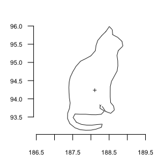

```r
shapes[4] %>% coo_smooth(5) %>% coo_sample(64) %>% coo_scale() %>% coo_plot()
```

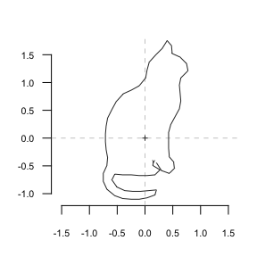

```r
# pipes can be turned into custom function
cs64 <- function(x) x %>% coo_sample(64) %>% coo_scale() %>% coo_center()
shapes[4] %>% cs64 %>% coo_plot() # note the axes
```

Have a look to the dedicated vignette with `vignette("Momocs_coo")`.

The most familiar operation can directly be applied on `Coo` objects:

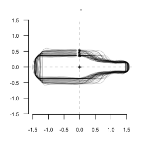

```
## Out (outlines)
##   - 40 outlines, 162 +/- 21 coords (in $coo)
##   - 2 classifiers (in $fac):
## # A tibble: 40 × 2
##   type   fake
##   <fct>  <fct>
## 1 whisky a
## 2 whisky a
## 3 whisky a
## 4 whisky a
## 5 whisky a
## 6 whisky a
## # … with 34 more rows
##   - also: $ldk
```

```r
bot %>%
  coo_center %>% coo_scale %>%
  coo_alignxax() %>% coo_slidedirection("up") %T>%
  print() %>% stack()
```

## Morphometrics

### Outline analysis

A word about data import: you can extract outlines from a list of black masks over a white background, as `.jpg` images with `import_jpg`. Have a look to helpfiles (`import_jpg` and `import_jpg1`) for more details. Here we do not bother with import since we will use the `bot`tles outlines dataset bundled with Momocs.

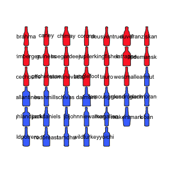

```r
data(bot)
bot
panel(bot, fac="type", names=TRUE)
```

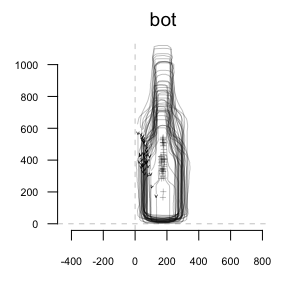

[output not shown]

```r
stack(bot)
```

Here, we will illustrate outline analysis with elliptical Fourier transforms (but the less used and tested `rfourier`, `sfourier` and `tfourier` are also implemented).

The idea behind elliptical Fourier transforms is to fit the `x` and `y` coordinates separately, that is the blue and red curves below:

[figure not shown]

```
## # A tibble: 138 × 2
##       dx    dy
##    <dbl> <dbl>
##  1     0     0
##  2     3   -21
##  3     3   -32
##  4     6   -53
##  5     9   -74
##  6    11   -84
##  7    15  -105
##  8    17  -126
##  9    20  -147
## 10    22  -158
## # … with 128 more rows
```

```r
coo_oscillo(bot[1], "efourier")
```

Graphically, this is equivalent to fitting Ptolemaic ellipses on the plane, try the following:

```r
Ptolemy(bot[1])
```

Let’s calibrate the number of harmonics required. More details can be found in their respective help files. Try the following:

```r
bot.f <- efourier(bot, nb.h=10)
bot.f
```

```
## An OutCoe object [ elliptical Fourier analysis ]
## --------------------
##  - $coe: 40 outlines described, 10 harmonics
## # A tibble: 40 × 2
##   type   fake
##   <fct>  <fct>
## 1 whisky a
## 2 whisky a
## 3 whisky a
## 4 whisky a
## 5 whisky a
## 6 whisky a
## # … with 34 more rows
```

`bot.f` is a `Coe` object (and even an `OutCoe`), you have have a look to the help files to go deeper into Momocs classes.

You can have a look to the amplitude of fitted coefficients with:

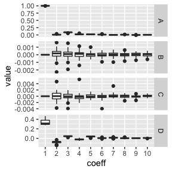

```r
boxplot(bot.f, drop=1)
```

Now, we can calculate a PCA on the `Coe` object and plot it, along with morphospaces, calculated on the fly.

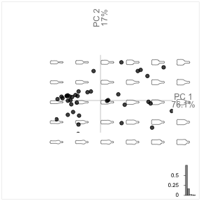

```
## [1] "PCA"    "prcomp"
```

```r
bot.p <- PCA(bot.f)
class(bot.p)        # a PCA object, let's plot it
plot_PCA(bot.p)
```

Amazing but we will do much better afterwards.

The question of normalization in elliptical Fourier transforms is central: have a look to `?efourier`.

You can also drop some harmonics with `rm_harm`. And methods that removes the bilateral (a)symmetry are implemented: `rm_asym` and `rm_sym`, while `symmetry` calculates some related indices.

### Open outlines

Open outlines are curves. Methods actually implemented are:

- `npoly` that fit natural polynomials;
- `opoly` that fit orthogonal (also called Legendre’s) polynomials;
- `dfourier` for the discrete cosine transform.

Note that `opoly` and `npoly` can only be used on *simple* curves, curves that have at most one `y` for any `x` coordinates, at least under a given orientation. `dfourier` can fit *complex* curves, curves “that back on their feets”.

Here, we will work on the fertile valves of olive stones, a (very partial) dataset provided by my colleagues Terral, Ivorra, and others.

They have two orthogonal views (a lateral and a dorsal view). See the paper cited in `?olea` for more details. Let’s explore it a bit:

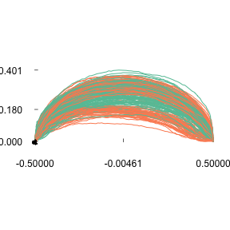

```
## Opn (curves)
##   - 210 curves, 99 +/- 4 coords (in $coo)
##   - 4 classifiers (in $fac):
## # A tibble: 210 × 4
##   var   domes view  ind
##   <fct> <fct> <fct> <fct>
## 1 Aglan cult  VD    O10
## 2 Aglan cult  VL    O10
## 3 Aglan cult  VD    O11
## 4 Aglan cult  VL    O11
## 5 Aglan cult  VD    O12
## 6 Aglan cult  VL    O12
## # … with 204 more rows
##   - also: $ldk
```

```r
olea
pile(olea, ~view)    # a family picture colored by a factor
```

Now, we gonna calculate `opoly` on it and plot the result of the PCA. Notice how consistent is the grammar and the objects obtained:

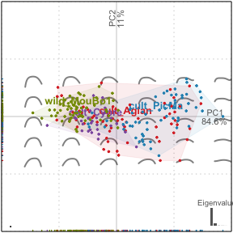

```
## [1] "OpnCoe" "Coe"
## [1] "PCA"    "prcomp"
```

```r
op <- opoly(olea)           # orthogonal polynomials
class(op)                   # an OpnCoe, but also a Coe
op.p <- PCA(op)             # we calculate a PCA on it
class(op.p)                 # a PCA object
op %>% PCA %>% plot(~domes+var)   # notice the formula interface to combine factors
```

But this is perfectly wrong! We merged the two views are if they were different individuals. Momocs can first `chop` or `filter` the whole dataset to separate the two views, do morphometrics on them, and `combine` them afterwards.

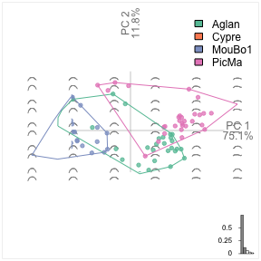

```
##     var
## view Aglan Cypre MouBo1 PicMa
##   VD    30    30     30    30
##   VL    30     0     30    30
## An OpnCoe object [ combined: opoly + opoly analyses ]
## --------------------
##  - $coe: 90 open outlines described
##  - $baseline1: (-0.5; 0; -0.5; 0)
##  - $baseline2: (0.5; 0; 0.5; 0)
## # A tibble: 90 × 4
##   var   domes view  ind
##   <fct> <fct> <fct> <fct>
## 1 Aglan cult  VD    O10
## 2 Aglan cult  VD    O11
## 3 Aglan cult  VD    O12
## 4 Aglan cult  VD    O13
## 5 Aglan cult  VD    O14
## 6 Aglan cult  VD    O15
## # … with 84 more rows
```

```r
with(olea$fac, table(view, var))
# we drop 'Cypre' since there is no VL for 'Cypre' var
olea %>% filter(var != "Cypre") %>%
# split, do morphometrics, combine
chop(~view) %>% opoly %>% combine() %T>%
# we print the OpnCoe object, then resume to the pipe
print() %>%
# note the two views in the morphospace
PCA() %>% plot_PCA(~var)
```

Now the PCA is done on the combination of two `OpnCoe` objects, each one resulting from an independant `opoly` call. That is the meaning of the `[ combined: opoly + opoly analyses ]` printed by the pipe above. Momocs can combine up to four different views.

### Configuration of landmarks

_Landmarks methods are still quite experimental (i.e. not tested extensively)

Let’s have a look to graphics facilities and apply a full generalized Procrustes adjustment:

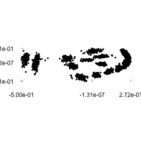

```r
pile(wings)
```

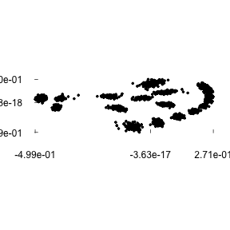

```r
options(Momocs_verbose=FALSE) # to silent Momocs
w.al <- fgProcrustes(wings)
pile(w.al)
```

[figure not shown]

```r
# PCA
PCA(w.al) %>% plot_PCA(1)
```

Sliding landmarks are supported and rely on `geomorph` package by Adams and colleagues.

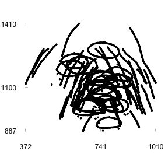

```r
pile(chaff)
```

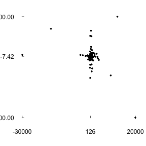

```r
chaff.al <- fgsProcrustes(chaff)
pile(chaff.al)
```

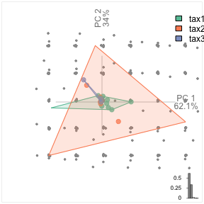

[output not shown]

```r
chaff.al %>% PCA() %>% plot_PCA(~taxa, chullfilled = TRUE)
```

Again, the grammar is consistent for landmarks.

### Traditional morphometrics

Traditional morphometrics lose geometries: from the variables, you can’t unambiguously reconstruct the shape. Every shape is described by a combination of measurements, (inter landmark distance, quantitative variables, scalar descriptor, etc.)

Momocs provides some basics utilities to work with such objects in the `TraCoe` class. There is not `TraCoo` per se but it can be obtained from any `Coo` with the `measure` method. Let’s take the `hearts` dataset that comes from handdrawn heart shapes from my former colleagues at the French Intitute of Pondicherry:

[figure not shown]

```
## Out (outlines)
##   - 240 outlines, 80 +/- 0 coords (in $coo)
##   - 1 classifiers (in $fac):
## # A tibble: 240 × 1
##   aut
##   <fct>
## 1 ced
## 2 ced
## 3 ced
## 4 ced
## 5 ced
## 6 ced
## # … with 234 more rows
##   - also: $ldk
```

```r
hearts
panel(hearts, fac="aut", names="aut")
```

Notice that there are 4 landmarks defined on them. Such landmarks on outlines can be: defined with`def_ldk()`, retrieved with `get_ldk()`, and overall used to align outlines with `fgProcrustes()`. You can compare: `hearts %>% stack()` with `hearts %>% fgProcrustes() %>% coo_slide(ldk=1) %>% stack()`.

Let’s describe these hearts with scalar descriptors: area, circularity and the distance between the 1st and the 3rd bumps of the hearts. `measure` is of great help. Note the loadings.

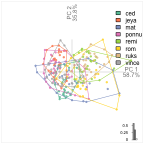

```
## [1] "TraCoe" "Coe"
## # A tibble: 240 × 3
##     area circularity   d1.3
##    <dbl>       <dbl>  <dbl>
##  1 0.627        14.0 0.0695
##  2 0.593        14.5 0.0639
##  3 0.611        16.1 0.0699
##  4 0.539        15.7 0.0627
##  5 0.541        13.6 0.0613
##  6 0.611        16.0 0.0692
##  7 0.617        16.5 0.0755
##  8 0.535        15.8 0.0655
##  9 0.521        14.3 0.0622
## 10 0.546        15.2 0.0642
## # … with 230 more rows
```

```r
ht <- measure(hearts, coo_area, coo_circularity, d(1, 3))
class(ht)
ht$coe
ht %>% PCA() %>% plot_PCA(~aut)
```

Again, there are plenty of scalar descriptors of shape, which names starts with `coo_*`, `apropos("coo_")`. Have a look to the coo_vignette, see `vignette("Momocs_coo")`.

Such a `TraCoe` is provided in the `flower` dataset which is simply a rearranged `iris`. Once again, note the grammar consistency.

```r
flower
flower %>% PCA() %>% plot_PCA(~sp)
```

[output not shown]

You can build your own `TraCoe` with `coo_scalars`:

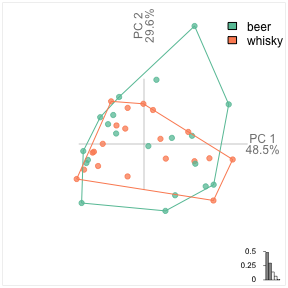

```r
bot_sc <- bot %>% coo_scalars %>% TraCoe(fac=bot$fac)
bot_sc %>% PCA %>% plot_PCA(~type)
```

Note that, by default, PCA on `TraCoe` object first centers and scales variables. This can be changed, see `?PCA`.

## Multivariate statistics

This section will mainly be illustrated with `bot`, and consequently outline analysis, but it works exactly the same on any `Coe` object, resulting from open outlines, configuration of landmarks, traditional morphometrics, etc.

```r
bot.f <- efourier(bot)
```

### `PCA`: Principal Component Analysis

Let’s see the main components of shape variability with a Principal Component Analysis.

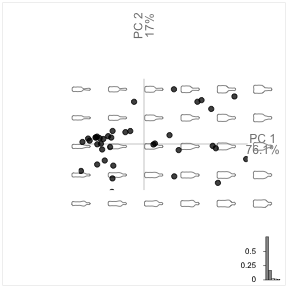

```r
bot.p <- PCA(bot.f)
plot_PCA(bot.p)
```

Morphological spaces are reconstructed on the fly with `plot.PCA`. We call it `plot.PCA` because it uses the familiar `plot` but on the particular `PCA` class (type `class(bot.p)`). We may want to display the two groups saved in `bot$fac`. Just type the id of the column or its name.

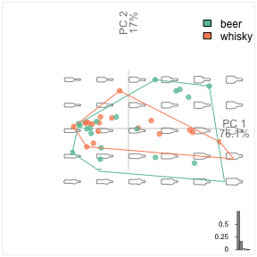

```r
plot_PCA(bot.p, ~type) # there are many ways to pass the factor, see ?plot_PCA and ?fac_dispatcher
```

See `?plot_PCA` for much more complex graphics. And also these helper functions for the `PCA` class:

```r
scree(bot.p)
scree_plot(bot.p)
boxplot(bot.p, 1)
PCcontrib(bot.p, nax = 1:3)
```

You can also export the `PCA` object as a `.txt` file (see `?export`) or as a `data_frame` for further use with R with:

```r
bot.p %>% as_df(3) # The first three PCs
```

```
## # A tibble: 40 × 5
##    type   fake      PC1       PC2      PC3
##    <fct>  <fct>   <dbl>     <dbl>    <dbl>
##  1 whisky a     -0.0528 -0.0231    0.00245
##  2 whisky a     -0.0369  0.00725  -0.00866
##  3 whisky a      0.0809 -0.00479  -0.00222
##  4 whisky a     -0.0694  0.00229  -0.0158
##  5 whisky a     -0.0112  0.0476   -0.0127
##  6 whisky a      0.115  -0.0170   -0.0103
##  7 whisky a     -0.0443 -0.0186   -0.00496
##  8 whisky a      0.0287  0.00996  -0.0114
##  9 whisky a      0.0123  0.000603  0.00364
## 10 whisky a     -0.0458  0.00564  -0.00889
## # … with 30 more rows
```

By the way, you can use Momocs plotters to plot non-morphometric datasets. Using a `TraCoe` object is an option, but `PCA` also works fine. Let’s see an example with `iris` dataset:

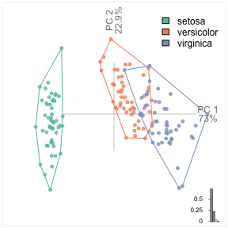

```r
TraCoe(iris[, -5], fac=data.frame(sp=iris$Species)) %>%
PCA() %>% plot_PCA(~sp)
```

### `LDA`: Linear Discriminant Analysis

We can also calculate a Linear Discriminant Analysis on the PCA scores, or on the `Coe` object, directly on the matrix of coefficients (and results may be better yet we may encounter collinearity between variables). Try the following:

```r
#LDA(bot.f, 1)
# we work on PCA scores
bot.l <- LDA(bot.p, 1)
# print a summary, along with the leave-one-out cross-validation table.
bot.l
# a much more detailed summary
bot.l %>% summary
# plot.LDA works pretty much with the same grammar as plot.PCA
# here we only have one LD
plot(bot.l)
# plot the cross-validation table
plot_CV(bot.l)  # tabular version
```

You can also export turn it into a `data_frame` with `as_df`.

### `MANOVA`: Multivariate Analysis of (co)variace

We can test for a difference in the distribution of PC scores with:

```r
MANOVA(bot.p,  ~type)
```

```
##           Df Hotelling-Lawley approx F num Df den Df   Pr(>F)
## fac        1           2.8388   12.977      7     32 8.88e-08 ***
## Residuals 38
## ---
## Signif. codes:  0 '***' 0.001 '**' 0.01 '*' 0.05 '.' 0.1 ' ' 1
```

We can also calculate pairwise combination between every levels of a `fac`. Here we just have two levels, so a single pairwise combination but the syntax is:

```r
MANOVA_PW(bot.p, ~type)
```

```
## $stars.tab
##      beer whisky
## beer      ***
##
## $summary (see also $manovas)
##               Df Pillai approx F num Df den Df   Pr(>F)
## beer - whisky  1 0.7395    12.98      7     32 8.88e-08
```

If we want a MANCOVA instead :

```r
bot %<>% mutate(cs=coo_centsize(.))
bot %>% efourier %>% PCA %>% MANOVA(~cs)
```

```
##           Df Hotelling-Lawley approx F num Df den Df Pr(>F)
## fac        1          0.38135   1.7433      7     32 0.1341
## Residuals 38
```